# Session 10: Data Science Capstone Project

Dr Kanishka Bhattacharya

2022-11-08

# 1 Introduction and learning objectives

The purpose of this exercise is to build an estimation engine to guide investment decisions in London house market. You will first build machine learning algorithms (and tune them) to estimate the house prices given variety of information about each property. Then, using your algorithm, you will choose 200 houses to invest in out of about 2000 houses on the market at the moment.

**Learning objectives**

1. Using different data mining algorithms for prediction.
2. Dealing with large data sets
3. Tuning data mining algorithms
4. Interpreting data mining algorithms and deducing importance of variables
5. Using results of data mining algorithms to make business decisions

# 2 Load data

There are two sets of data, i) training data that has the actual prices ii) out of sample data that has the asking prices. Load both data sets.

Make sure you understand what information each column contains. Note that not all information provided might be useful in predicting house prices, but do not make any assumptions before you decide what information you use in your prediction algorithms.

```r
#read in the data

london_house_prices_2019_training<-read.csv("training_data_assignment_with_prices.csv")
london_house_prices_2019_out_of_sample<-read.csv("test_data_assignment.csv")



#fix data types in both data sets

#fix dates
london_house_prices_2019_training <- london_house_prices_2019_training %>% mutate(date=as.Date(date))
london_house_prices_2019_out_of_sample<-london_house_prices_2019_out_of_sample %>% mutate(date=as.Date(date))
#change characters to factors
london_house_prices_2019_training <- london_house_prices_2019_training %>% mutate_if(is.character,as.factor)
london_house_prices_2019_out_of_sample<-london_house_prices_2019_out_of_sample %>% mutate_if(is.character,as.factor)

#take a quick look at what's in the data
str(london_house_prices_2019_training)
```

```
## 'data.frame':    13998 obs. of  37 variables:
##  $ ID                          : int  2 3 4 5 7 8 9 10 11 12 ...
##  $ date                        : Date, format: "2019-11-01" "2019-08-08" ...
##  $ postcode                    : Factor w/ 12635 levels "BR1 1AB","BR1 1LR",..: 10897 11027 11264 2031 11241 11066 421 9594 9444 873 ...
##  $ property_type               : Factor w/ 4 levels "D","F","S","T": 2 2 3 2 3 2 1 4 4 2 ...
##  $ whether_old_or_new          : Factor w/ 2 levels "N","Y": 1 1 1 1 1 1 1 1 1 1 ...
##  $ freehold_or_leasehold       : Factor w/ 2 levels "F","L": 2 2 1 2 1 2 1 1 1 2 ...
##  $ address1                    : Factor w/ 2825 levels "1","1 - 2","1 - 3",..: 2503 792 253 789 569 234 264 418 5 274 ...
##  $ address2                    : Factor w/ 434 levels "1","10","101",..: 372 NA NA NA NA NA NA NA NA NA ...
##  $ address3                    : Factor w/ 8543 levels "ABBERTON WALK",..: 6990 6821 3715 2492 4168 2879 3620 5251 6045 6892 ...
##  $ town                        : Factor w/ 133 levels "ABBEY WOOD","ACTON",..: NA NA NA 78 NA NA NA NA NA NA ...
##  $ local_aut                   : Factor w/ 69 levels "ASHFORD","BARKING",..: 36 46 24 36 24 46 65 36 36 17 ...
##  $ county                      : Factor w/ 33 levels "BARKING AND DAGENHAM",..: 22 27 18 25 18 27 5 27 32 8 ...
##  $ postcode_short              : Factor w/ 247 levels "BR1","BR2","BR3",..: 190 194 198 28 198 194 4 169 167 8 ...
##  $ current_energy_rating       : Factor w/ 6 levels "B","C","D","E",..: 4 3 3 4 3 2 4 3 4 2 ...
```

[output cut: 23 more lines]

```r
str(london_house_prices_2019_out_of_sample)
```

```
## 'data.frame':    1999 obs. of  37 variables:
##  $ ID                          : int  14434 12562 8866 10721 1057 1527 13961 12108 9363 1155 ...
##  $ date                        : Date, format: NA NA ...
##  $ postcode                    : logi  NA NA NA NA NA NA ...
##  $ property_type               : Factor w/ 4 levels "D","F","S","T": 1 2 2 3 4 3 2 3 2 4 ...
##  $ whether_old_or_new          : Factor w/ 2 levels "N","Y": 1 1 1 1 1 1 1 1 1 1 ...
##  $ freehold_or_leasehold       : Factor w/ 2 levels "F","L": 1 2 2 1 1 1 2 1 2 1 ...
##  $ address1                    : logi  NA NA NA NA NA NA ...
##  $ address2                    : logi  NA NA NA NA NA NA ...
##  $ address3                    : logi  NA NA NA NA NA NA ...
##  $ town                        : Factor w/ 54 levels "ACTON","ADDISCOMBE",..: NA NA NA NA NA NA NA NA NA NA ...
##  $ local_aut                   : logi  NA NA NA NA NA NA ...
##  $ county                      : logi  NA NA NA NA NA NA ...
##  $ postcode_short              : Factor w/ 221 levels "BR1","BR2","BR3",..: 82 50 37 52 214 150 159 115 175 126 ...
##  $ current_energy_rating       : Factor w/ 6 levels "B","C","D","E",..: 3 2 3 3 4 4 4 3 4 3 ...
```

[output cut: 23 more lines]

```r
#let's do the initial split
library(rsample)
train_test_split <- initial_split(london_house_prices_2019_training, prop = 0.75) #training set contains 75% of the data
# Create the training dataset
train_data <- training(train_test_split)
test_data <- testing(train_test_split)
```

# 3 Visualize data

Visualize and examine the data. What plots could be useful here? What do you learn from these visualizations?

Estimate a correlation table between prices and other continuous variables. What do you glean from the correlation table?

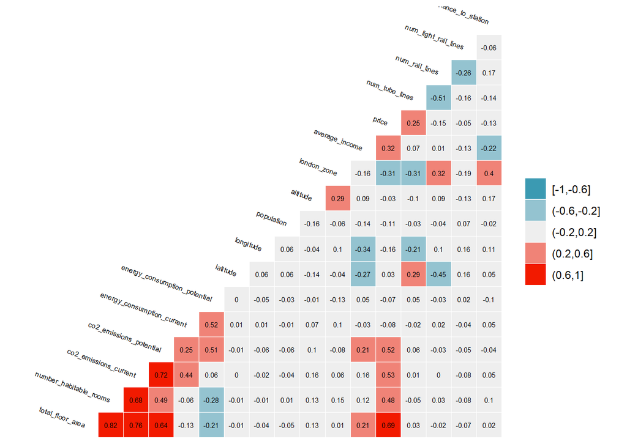

```r
# produce a correlation table using GGally::ggcor()
# this takes a while to plot

library("GGally")
london_house_prices_2019_training %>%
  select(-ID) %>% #keep Y variable last
  ggcorr(method = c("pairwise", "pearson"), layout.exp = 2,label_round=2, label = TRUE,label_size = 2,hjust = 1,nbreaks = 5,size = 2,angle = -20)
```

# 4 Fit a linear regression model

To help you get started I build a linear regression model below. I chose a subset of the features with no particular goal. You can (and should) add more variables and/or choose variable selection methods if you want.

```r
#Define control variables
control <- trainControl (
    method="cv",
    number=5,
    verboseIter=TRUE) #by setting this to true the model will report its progress after each estimation

#we are going to train the model and report the results using k-fold cross validation
model1_lm<-train(
    price ~ distance_to_station +water_company+property_type+whether_old_or_new+freehold_or_leasehold+latitude+ longitude,
    train_data,
   method = "lm",
    trControl = control
   )
# summary of the results
summary(model1_lm)
```

```
##
## Call:
## lm(formula = .outcome ~ ., data = dat)
##
## Residuals:
##      Min       1Q   Median       3Q      Max
##  -889873  -194896   -66215    69810 10007772
##
## Coefficients:
##                                       Estimate Std. Error t value Pr(>|t|)
## (Intercept)                          -48089660    3728889 -12.897  < 2e-16 ***
## distance_to_station                    -145931      12508 -11.667  < 2e-16 ***
## `water_companyEssex & Suffolk Water`    386337      29360  13.159  < 2e-16 ***
## `water_companyLeep Utilities`           558866     274560   2.035   0.0418 *
## `water_companySES Water`                274430      29920   9.172  < 2e-16 ***
## `water_companyThames Water`             487541      19853  24.558  < 2e-16 ***
## property_typeF                         -454492      40057 -11.346  < 2e-16 ***
## property_typeS                         -341965      21952 -15.578  < 2e-16 ***
## property_typeT                         -387689      21023 -18.441  < 2e-16 ***
## whether_old_or_newY                      74369     212212   0.350   0.7260
## freehold_or_leaseholdL                 -191180      34764  -5.499  3.9e-08 ***
## latitude                                946033      72280  13.088  < 2e-16 ***
## longitude                             -1013974      40770 -24.870  < 2e-16 ***
## ---
## Signif. codes:  0 '***' 0.001 '**' 0.01 '*' 0.05 '.' 0.1 ' ' 1
##
## Residual standard error: 474100 on 10485 degrees of freedom
## Multiple R-squared:  0.1763, Adjusted R-squared:  0.1754
## F-statistic: 187.1 on 12 and 10485 DF,  p-value: < 2.2e-16
```

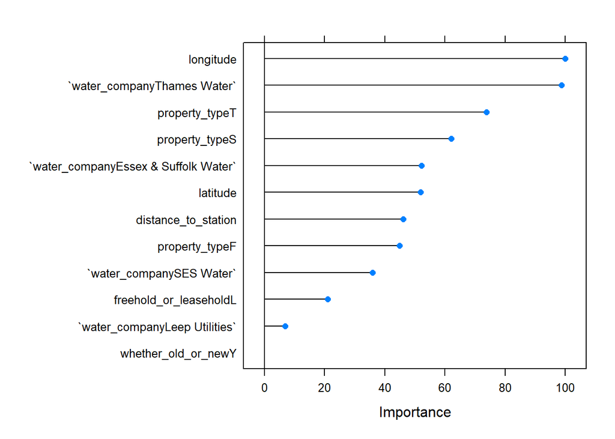

```r
# we can check variable importance as well
importance <- varImp(model1_lm, scale=TRUE)
plot(importance)
```

## 4.1 Predict the values in testing and out of sample data

Below I use the predict function to test the performance of the model in testing data and summarize the performance of the linear regression model. How can you measure the quality of your predictions?

```r
# We can predict the testing values

predictions <- predict(model1_lm,test_data)

lr_results<-data.frame(  RMSE = RMSE(predictions, test_data$price),
                            Rsquare = R2(predictions, test_data$price))


lr_results
```

```
##       RMSE   Rsquare
## 1 459559.4 0.1888042
```

```r
#We can predict prices for out of sample data the same way
predictions_oos <- predict(model1_lm,london_house_prices_2019_out_of_sample)
```

# 5 Fit a tree model

Compare the performance of the linear regression model with the tree model; which one performs better? Why do you think that is the case?

```r
model2_tree <- train(
  price ~ distance_to_station +water_company+property_type+whether_old_or_new+latitude+ longitude,
  train_data,
  method = "rpart",
  trControl = control,
  tuneLength=10
    )
#You can view how the tree performs
model2_tree$results
```

```
##             cp     RMSE   Rsquared      MAE   RMSESD   RsquaredSD     MAESD
## 1  0.008652266 403838.1 0.41298025 212553.0 32234.12 0.0849783928  7663.605
## 2  0.008857900 404366.2 0.41142482 213460.5 31303.70 0.0832735408  5839.949
## 3  0.012870666 417828.0 0.37384989 226694.8 25619.05 0.1098709024  7699.129
## 4  0.012883751 417828.0 0.37384989 226694.8 25619.05 0.1098709024  7699.129
## 5  0.013553698 421864.9 0.36389224 228719.3 29918.60 0.0987380550  8148.428
## 6  0.013845369 423020.6 0.36106376 229366.2 31779.08 0.0940969981  8822.643
## 7  0.035474392 454359.1 0.24639362 238485.8 56909.86 0.0376622111 10526.696
## 8  0.047165800 472703.3 0.18133097 245324.8 58697.76 0.0360677156 11270.584
## 9  0.050064647 490605.2 0.10815193 257403.2 48841.23 0.0516517964 13858.719
## 10 0.052098604 511515.5 0.05036334 275343.0 54815.86 0.0008965125 12407.927
```

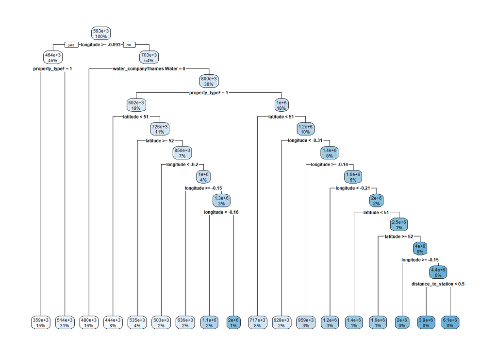

```r
#You can view the final tree
rpart.plot(model2_tree$finalModel)
```

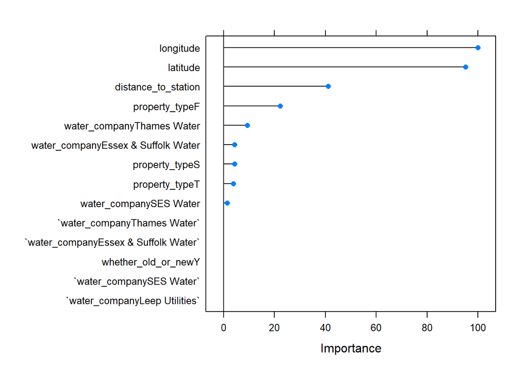

```r
#you can also visualize the variable importance
importance <- varImp(model2_tree, scale=TRUE)
plot(importance)
```

# 6 Other algorithms

Use at least two other algorithms to predict prices. Don’t forget to tune the parameters of these algorithms. And then compare the performances of your algorithms to linear regression and trees.

# 7 Stacking

Use stacking to ensemble your algorithms.

# 8 Pick investments

In this section you should use the best algorithm you identified to choose 200 properties from the out of sample data.

```r
numchoose=200

oos<-london_house_prices_2019_out_of_sample

#predict the value of houses
oos$predict <- predict(model2_tree,oos)
#Choose the ones you want to invest here
#Make sure you choose exactly 200 of them

#output your choices. Change the name of the file to your "lastname_firstname.csv"
write.csv(oos,"my_submission.csv")
```